# three

Bethany Poulin

9/20/2019

## Problem 3.1

The UC Irvine Machine Learning Repository6 contains a data set related to glass identification. The data consist of 214 glass samples labeled as one of seven class categories. There are nine predictors, including the refractive index and percentages of eight elements: Na, Mg, Al, Si, K, Ca, Ba, and Fe.

**(a) Using visualizations, explore the predictor variables to understand their distributions as well as the relationships between predictors.**

```r
require(mlbench)
require(psych)
data(Glass)
describe(Glass)
```

```
##       vars   n  mean   sd median trimmed  mad   min   max range  skew
## RI       1 214  1.52 0.00   1.52    1.52 0.00  1.51  1.53  0.02  1.60
## Na       2 214 13.41 0.82  13.30   13.38 0.64 10.73 17.38  6.65  0.45
## Mg       3 214  2.68 1.44   3.48    2.87 0.30  0.00  4.49  4.49 -1.14
## Al       4 214  1.44 0.50   1.36    1.41 0.31  0.29  3.50  3.21  0.89
## Si       5 214 72.65 0.77  72.79   72.71 0.57 69.81 75.41  5.60 -0.72
## K        6 214  0.50 0.65   0.56    0.43 0.17  0.00  6.21  6.21  6.46
## Ca       7 214  8.96 1.42   8.60    8.74 0.66  5.43 16.19 10.76  2.02
## Ba       8 214  0.18 0.50   0.00    0.03 0.00  0.00  3.15  3.15  3.37
## Fe       9 214  0.06 0.10   0.00    0.04 0.00  0.00  0.51  0.51  1.73
## Type*   10 214  2.54 1.71   2.00    2.31 1.48  1.00  6.00  5.00  1.04
##       kurtosis   se
## RI        4.72 0.00
## Na        2.90 0.06
## Mg       -0.45 0.10
## Al        1.94 0.03
## Si        2.82 0.05
## K        52.87 0.04
## Ca        6.41 0.10
## Ba       12.08 0.03
## Fe        2.52 0.01
## Type*    -0.29 0.12
```

Using a simple `describe( )` function we can see that there are som variables we will need to take closer looks at, with RI, Mg, K, Ca, Ba and Fe appearing skewed based on this table, and also RI, Na, Si, K , Ca,Ba and to a lesser extent Fe with some challenging tail shapes (kurtosis != 3.0)

### Skew of Numeric Variables

This can also be done using the package `e1071`:

```r
require(e1071)
skewer<-function(df){
    for(name in colnames(df)){
    skew <-skewness(df[,name])
    print(paste(colnames(df[name]),": ", skew))}
}

skewer(Glass[, 1:9])
```

```
## [1] "RI :  1.60271508274373"
## [1] "Na :  0.447834258917133"
## [1] "Mg :  -1.13645227846653"
## [1] "Al :  0.89461041611312"
## [1] "Si :  -0.720239210805621"
## [1] "K :  6.46008889572281"
## [1] "Ca :  2.01844629445302"
## [1] "Ba :  3.36867996880571"
## [1] "Fe :  1.7298107095598"
```

Looking at Histograms visually illustrates the challenges with these distributions.

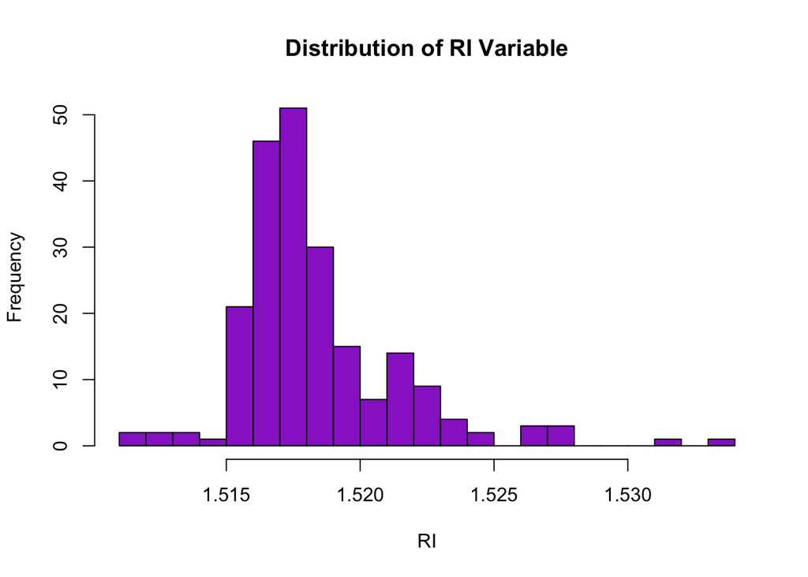

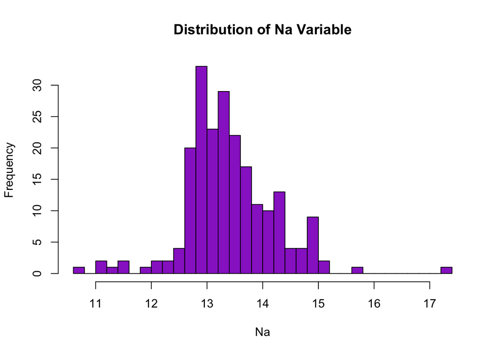

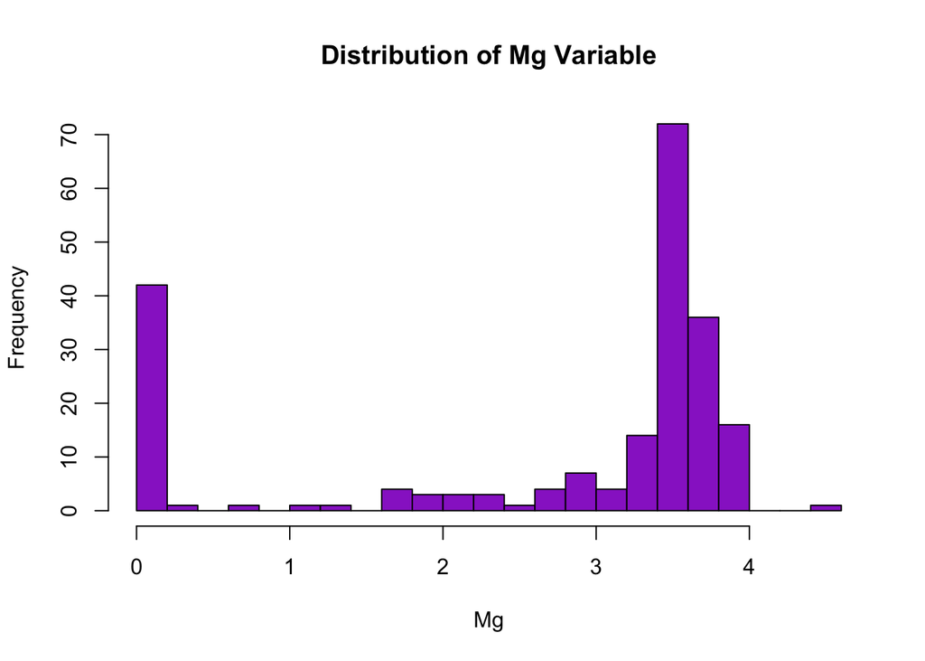

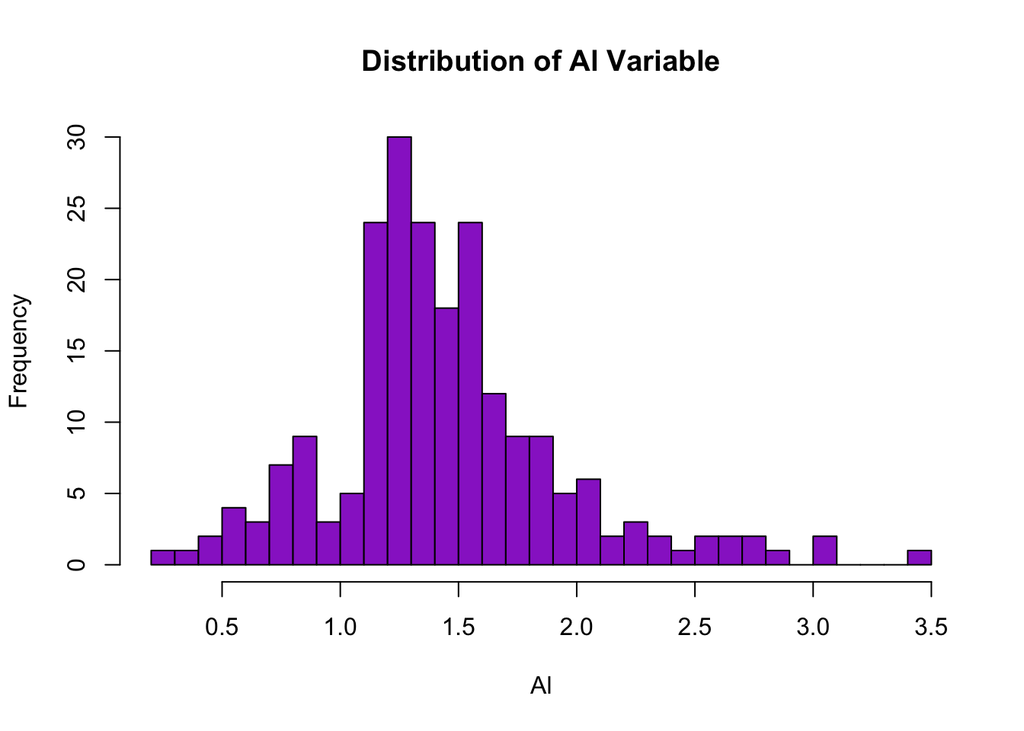

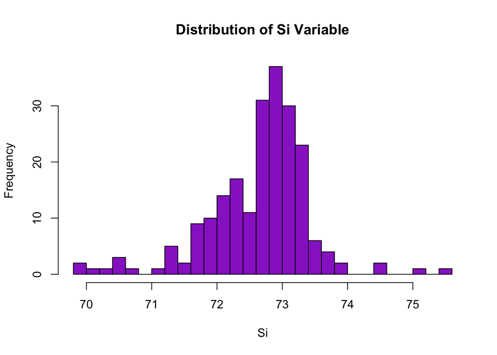

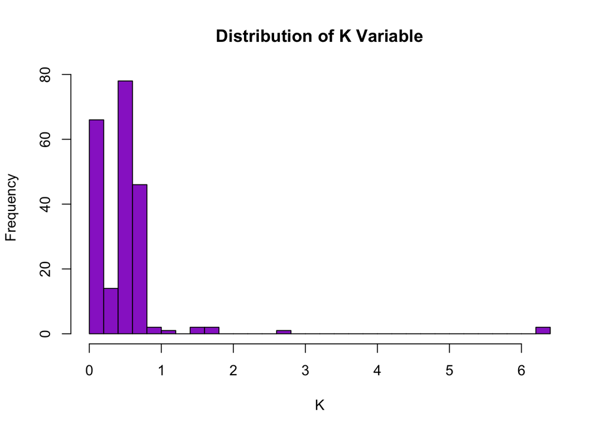

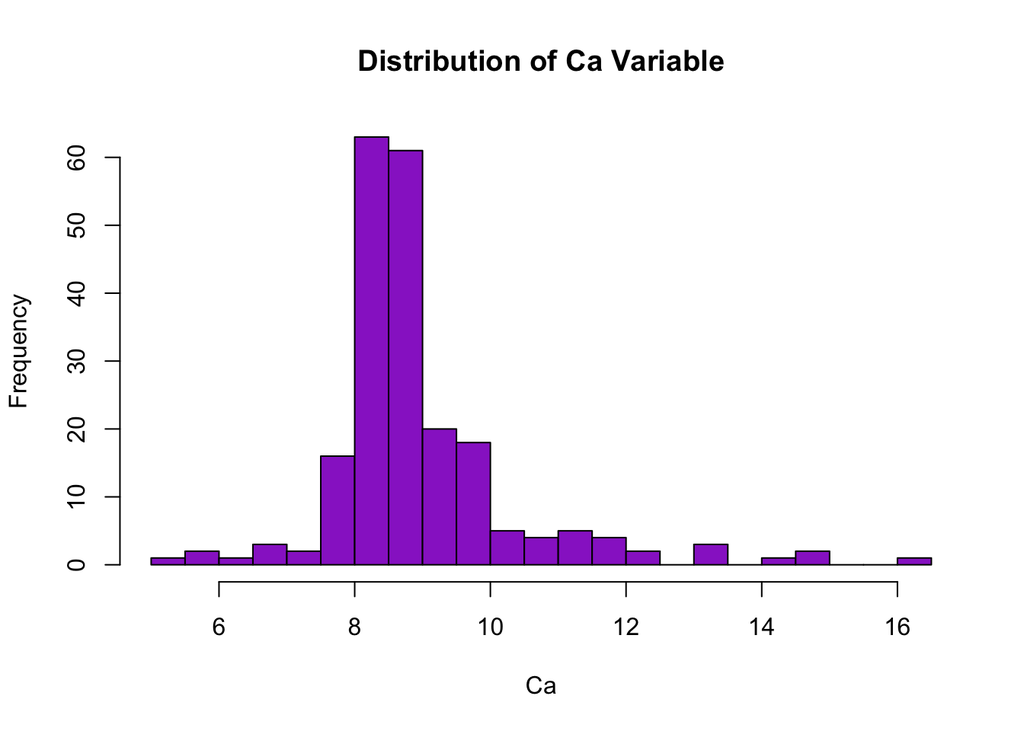

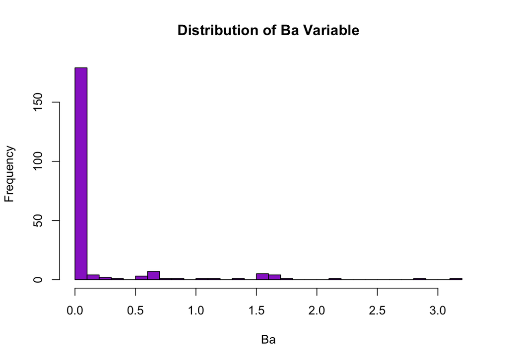

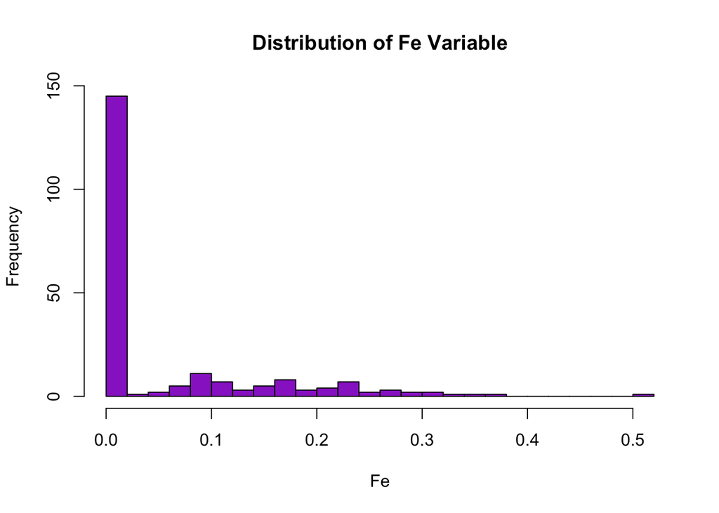

```r
require(caret)
require(corrplot)
#3.1


hist_plotter<-function(df){
    names_list = colnames(df)
    for (name in names_list){
        if (is.numeric(df[[name]])){
        hist(df[[name]],
             breaks = 30,
             main = paste0('Distribution of ', name, ' Variable'),
             col ='darkorchid',
             xlab=name)
            }
    }

}

hist_plotter(Glass)
```

### Correleations Between Numeric Glass Variables

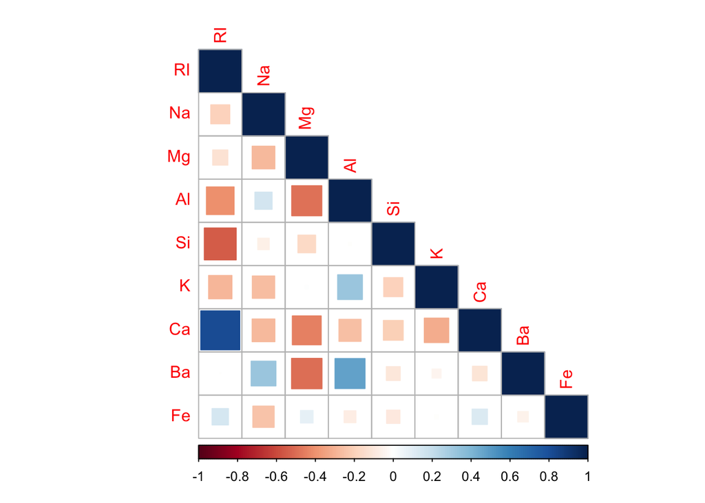

```r
glassCor <- cor(Glass[-10])
corrplot(glassCor, method = "square", type = "lower")
```

There is some significant positive corelation between Ca and RI as well as bit less between Ba and Al, as well as Ba and Na and K and Al,

There is some obvious negative correlations betweeen Si and RI as well as Al and RI, Al and Mg, Ca and Mg as well as Ba and Mg.

**(b) Do there appear to be any outliers in the data?**

Yes, there are outliers in several variables, RI, Na,K, Ca and Fe all have outliers past their contiguous right bounds which are visible in the histograms.

**Are any predictors skewed?**  
Yes, Mg is bimodal and Ba, K and Fe are right skewed, while the remaining variables are not really normal, they are both Leptokurtic and Platykurtic to some extent, but centrally tending.

This would suggest looking at the skew values as well as some possible transformations down the line might be of use!

**(c) Are there any relevant transformations of one or more predictors that might improve the classification model?**

**Simple Exploration of histograms for skewed distributions using `BoxCoxTrans( )`**

```r
skews <- c('Mg', 'Fe', 'Ba', 'Ca', 'K')


#MASS::boxcox(Glass)
for (skw in skews){
    print(skw)
    print(BoxCoxTrans(Glass[,skw]))
}
```

```
## [1] "Mg"
## Box-Cox Transformation
##
## 214 data points used to estimate Lambda
##
## Input data summary:
##    Min. 1st Qu.  Median    Mean 3rd Qu.    Max.
##   0.000   2.115   3.480   2.685   3.600   4.490
##
## Lambda could not be estimated; no transformation is applied
##
## [1] "Fe"
## Box-Cox Transformation
##
## 214 data points used to estimate Lambda
##
## Input data summary:
##    Min. 1st Qu.  Median    Mean 3rd Qu.    Max.
## 0.00000 0.00000 0.00000 0.05701 0.10000 0.51000
##
## Lambda could not be estimated; no transformation is applied
##
## [1] "Ba"
## Box-Cox Transformation
##
## 214 data points used to estimate Lambda
##
## Input data summary:
##    Min. 1st Qu.  Median    Mean 3rd Qu.    Max.
##   0.000   0.000   0.000   0.175   0.000   3.150
##
## Lambda could not be estimated; no transformation is applied
##
## [1] "Ca"
## Box-Cox Transformation
##
## 214 data points used to estimate Lambda
##
## Input data summary:
##    Min. 1st Qu.  Median    Mean 3rd Qu.    Max.
##   5.430   8.240   8.600   8.957   9.172  16.190
##
## Largest/Smallest: 2.98
## Sample Skewness: 2.02
##
## Estimated Lambda: -1.1
##
## [1] "K"
## Box-Cox Transformation
##
## 214 data points used to estimate Lambda
##
## Input data summary:
##    Min. 1st Qu.  Median    Mean 3rd Qu.    Max.
##  0.0000  0.1225  0.5550  0.4971  0.6100  6.2100
##
## Lambda could not be estimated; no transformation is applied
```

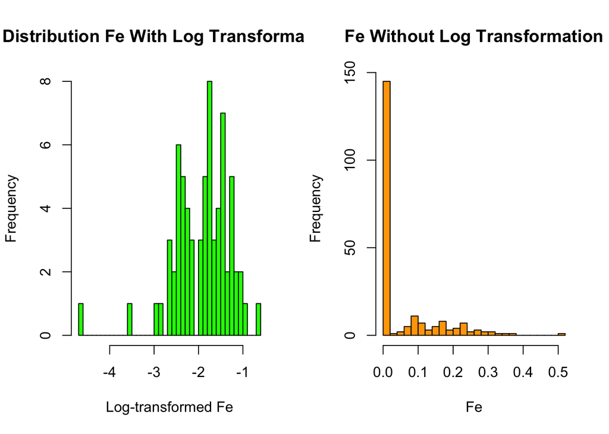

```r
require(caret)
par(mfrow=c(1,2))
hist(log(Glass$Fe),
     breaks = 30,
     col ='green',
     main ='Distribution Fe With Log Transformation',
     xlab ='Log-transformed Fe')
hist(Glass$Fe,
     breaks =30,
     col = 'orange',
     main = "Fe Without Log Transformation",
     xlab = 'Fe')
```

A simple log transformation does seem to show improvements in the distribution of the iron variable ‘Fe’, however it does introduce some outliers on the left, and all the zero values of Fe go to -Inf and are not reflected at all in this distribution .

### Working Through Box-Cox Transformation

Looking at the first few rows of the data before and after transformations to see what changes the Box-Cox method suggests

```r
head(Glass)
```

```
##        RI    Na   Mg   Al    Si    K   Ca Ba   Fe Type
## 1 1.52101 13.64 4.49 1.10 71.78 0.06 8.75  0 0.00    1
## 2 1.51761 13.89 3.60 1.36 72.73 0.48 7.83  0 0.00    1
## 3 1.51618 13.53 3.55 1.54 72.99 0.39 7.78  0 0.00    1
## 4 1.51766 13.21 3.69 1.29 72.61 0.57 8.22  0 0.00    1
## 5 1.51742 13.27 3.62 1.24 73.08 0.55 8.07  0 0.00    1
## 6 1.51596 12.79 3.61 1.62 72.97 0.64 8.07  0 0.26    1
```

```r
trans <- preProcess(Glass, method = c('center', 'scale', 'BoxCox'))

trans_glass <- predict(trans, Glass)


head(trans_glass)
```

```
##           RI         Na        Mg          Al          Si           K
## 1  0.8756898  0.3133883 1.2517037 -0.65520274 -1.12729016 -0.67013422
## 2 -0.2471367  0.6129977 0.6346799 -0.08726137  0.09719851 -0.02615193
## 3 -0.7216425  0.1798164 0.6000157  0.27454124  0.43512776 -0.16414813
## 4 -0.2305698 -0.2150217 0.6970756 -0.23439154 -0.05836211  0.11184428
## 5 -0.3101056 -0.1402661 0.6485456 -0.34194384  0.55238422  0.08117845
## 6 -0.7947626 -0.7480171 0.6416128  0.42852325  0.40909039  0.21917466
##            Ca         Ba         Fe Type
## 1 -0.01194308 -0.3520514 -0.5850791    1
## 2 -0.87918677 -0.3520514 -0.5850791    1
## 3 -0.93250264 -0.3520514 -0.5850791    1
## 4 -0.48665658 -0.3520514 -0.5850791    1
## 5 -0.63291627 -0.3520514 -0.5850791    1
## 6 -0.63291627 -0.3520514  2.0832652    1
```

### Histogram of Variables After Automated Application of Box-Cox transformations

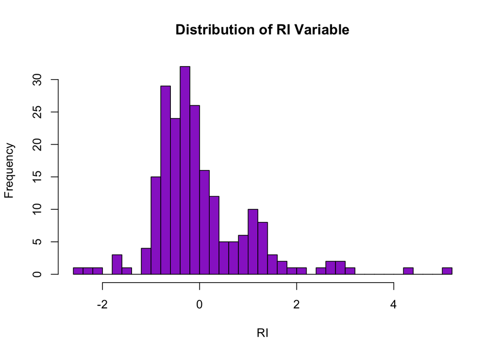

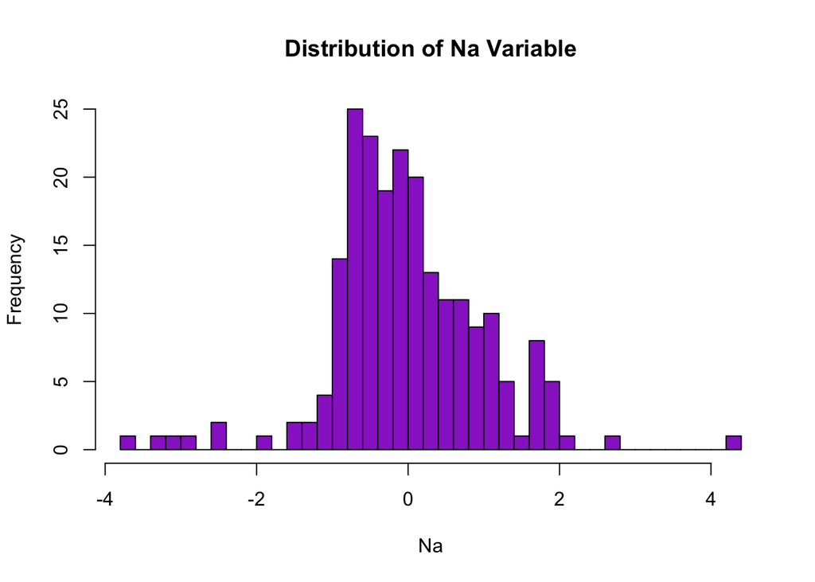

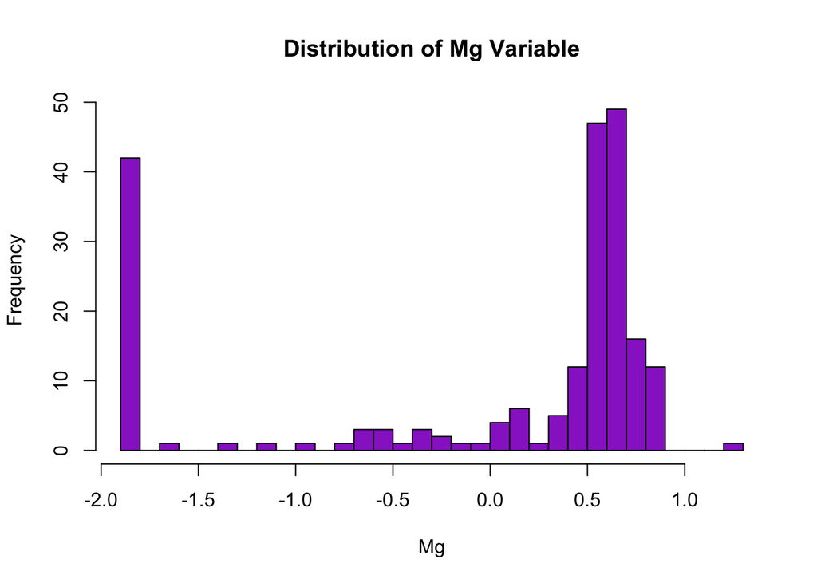

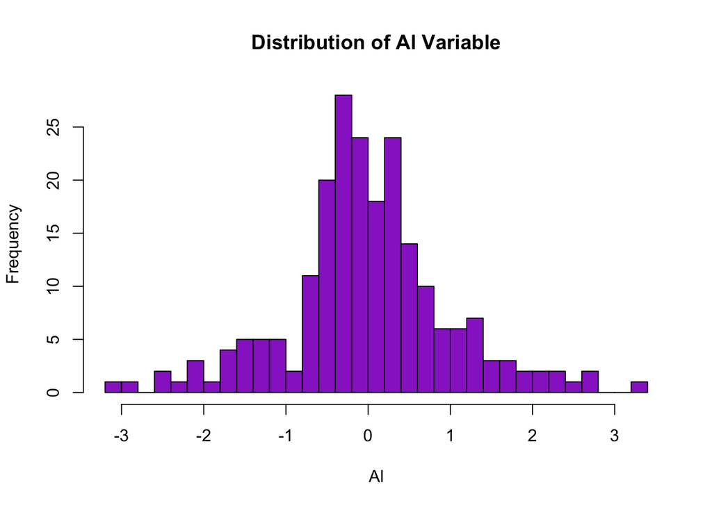

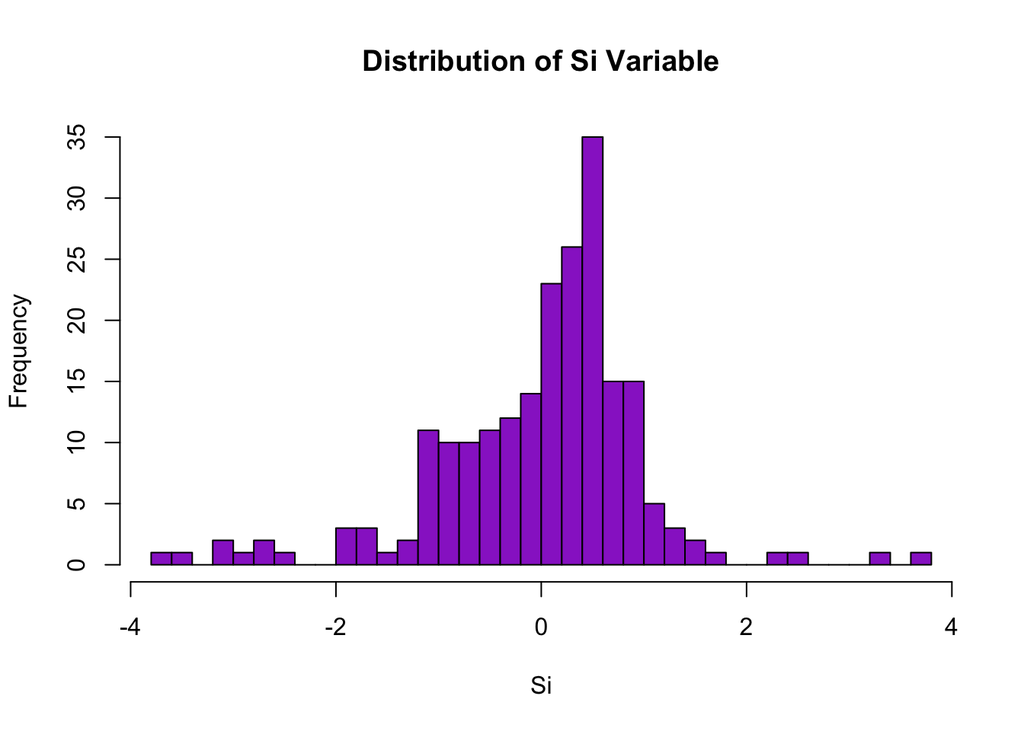

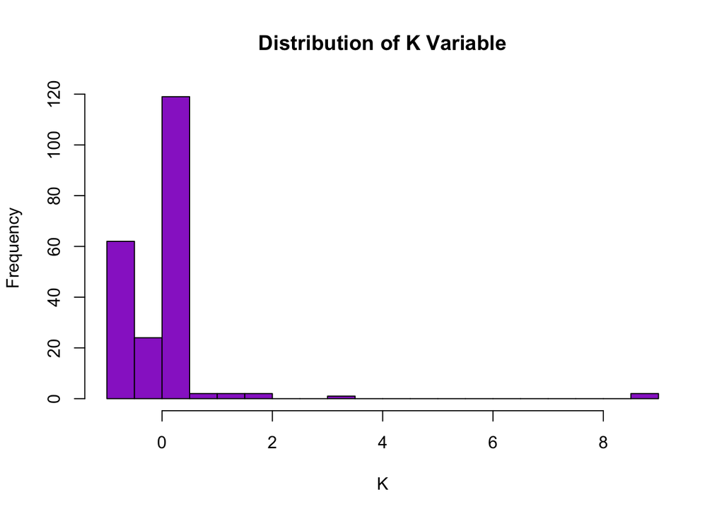

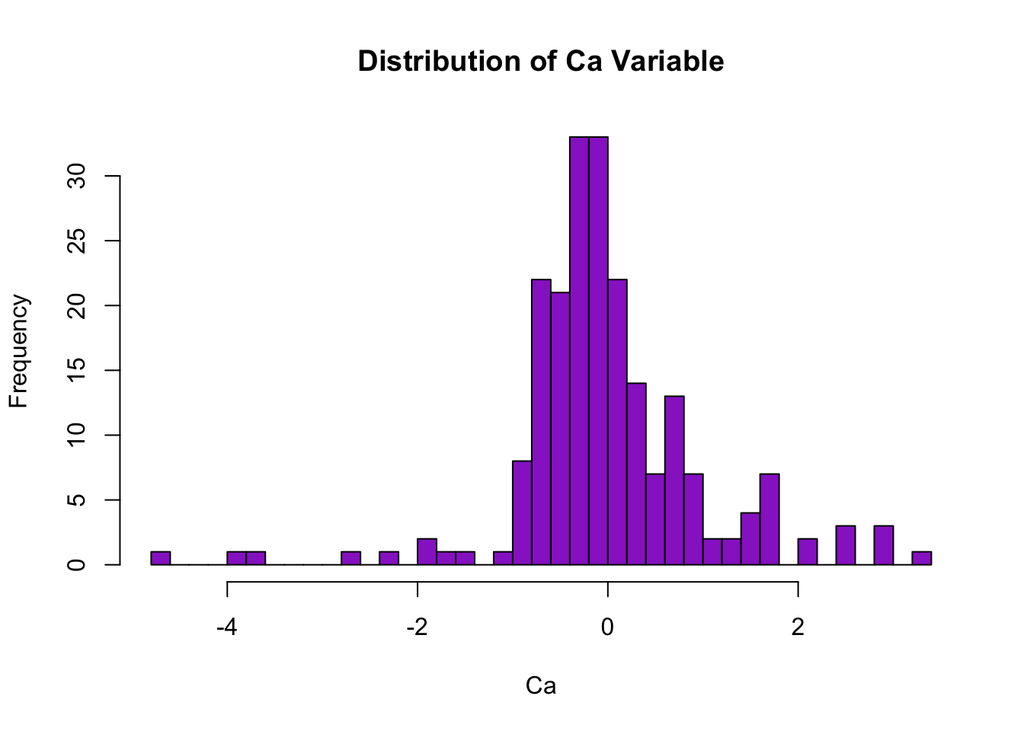

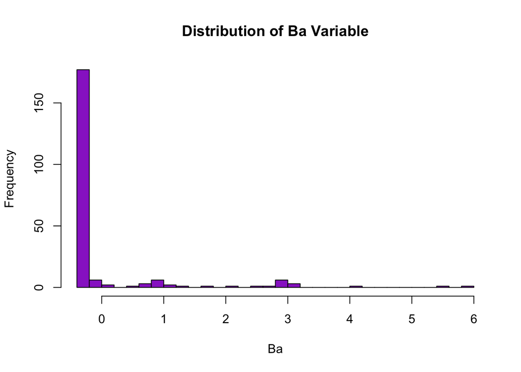

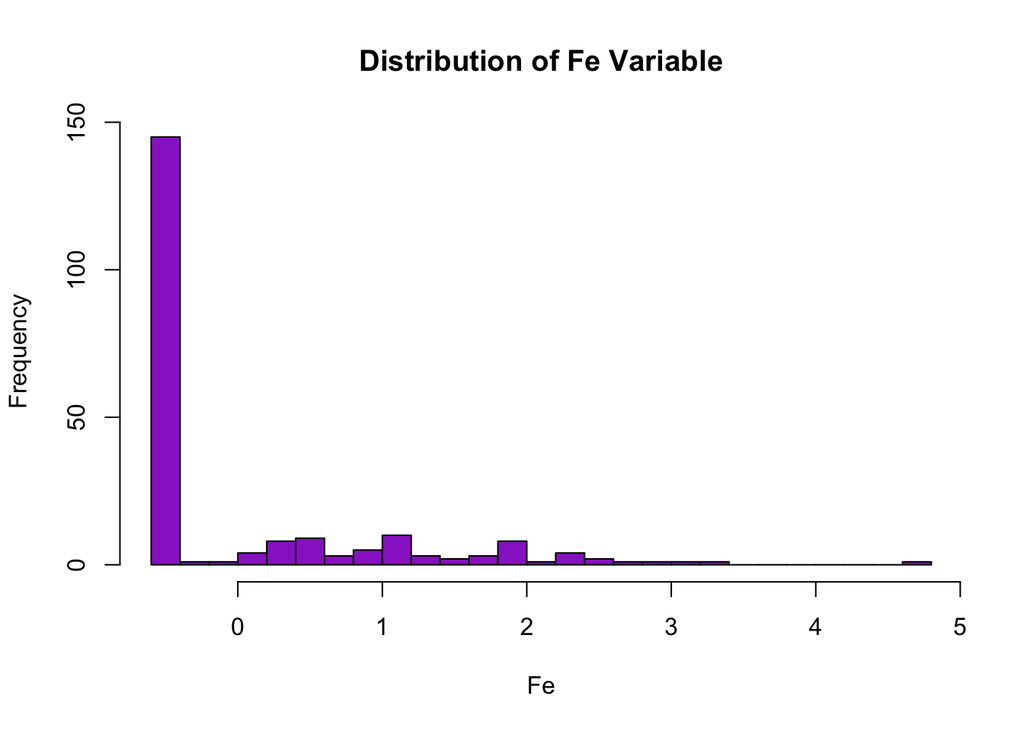

```r
hist_plotter(trans_glass)
```

Evaluating these histograms, there is marginal improvement in most of the variables, the only one with notable afffirmative changes is Ca. Given the commoness of outliers in this data set as well as skew, it maight be useful to try a `spatialSign()` transformation.

```r
trans <- preProcess(Glass, method = c('center', 'scale', 'spatialSign'))

trans_glass <- predict(trans, Glass)

head(Glass)
```

```
##        RI    Na   Mg   Al    Si    K   Ca Ba   Fe Type
## 1 1.52101 13.64 4.49 1.10 71.78 0.06 8.75  0 0.00    1
## 2 1.51761 13.89 3.60 1.36 72.73 0.48 7.83  0 0.00    1
## 3 1.51618 13.53 3.55 1.54 72.99 0.39 7.78  0 0.00    1
## 4 1.51766 13.21 3.69 1.29 72.61 0.57 8.22  0 0.00    1
## 5 1.51742 13.27 3.62 1.24 73.08 0.55 8.07  0 0.00    1
## 6 1.51596 12.79 3.61 1.62 72.97 0.64 8.07  0 0.26    1
```

```r
head(trans_glass)
```

```
##           RI          Na        Mg         Al          Si           K
## 1  0.3862138  0.12608198 0.5551342 -0.3063816 -0.49869486 -0.29720647
## 2 -0.1782866  0.42318047 0.4548937 -0.1218880  0.07316353 -0.01874385
## 3 -0.4739625  0.09851782 0.3951817  0.1254439  0.28831726 -0.10811108
## 4 -0.1932662 -0.20158533 0.5799799 -0.2581474 -0.04397201  0.09305653
## 5 -0.2268925 -0.12303180 0.4726731 -0.2991170  0.40373539  0.05916450
## 6 -0.3036441 -0.29004891 0.2459643  0.1344417  0.15791804  0.08402131
##            Ca         Ba         Fe Type
## 1 -0.06449657 -0.1561358 -0.2594843    1
## 2 -0.56756147 -0.2523255 -0.4193433    1
## 3 -0.54468469 -0.2318677 -0.3853442    1
## 4 -0.43085072 -0.2929133 -0.4867968    1
## 5 -0.45422808 -0.2565822 -0.4264175    1
## 6 -0.23892010 -0.1349600  0.7986264    1
```

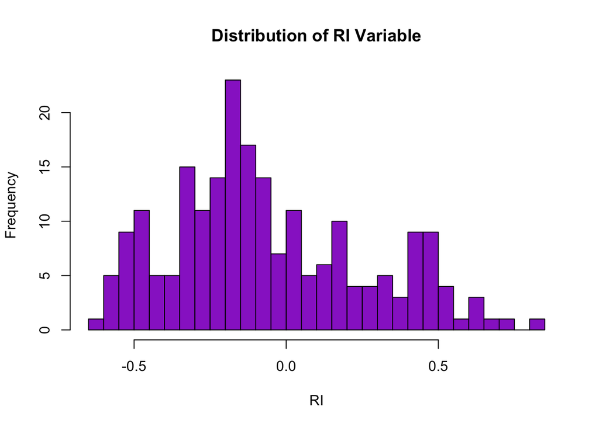

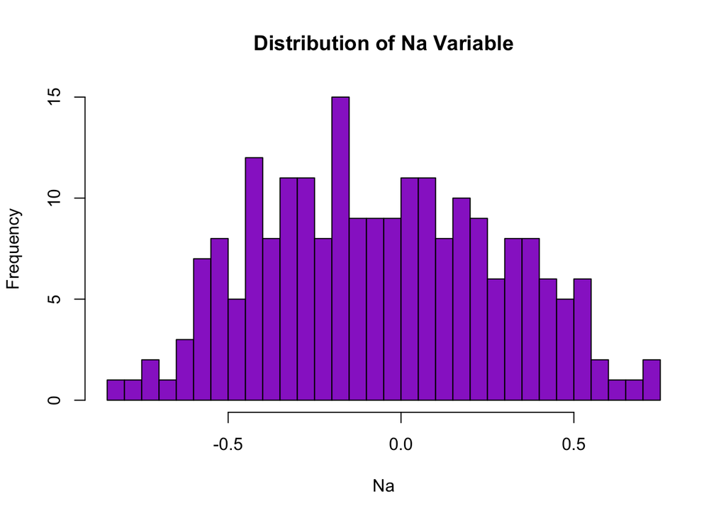

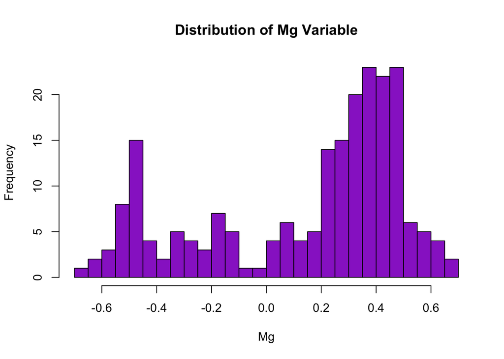

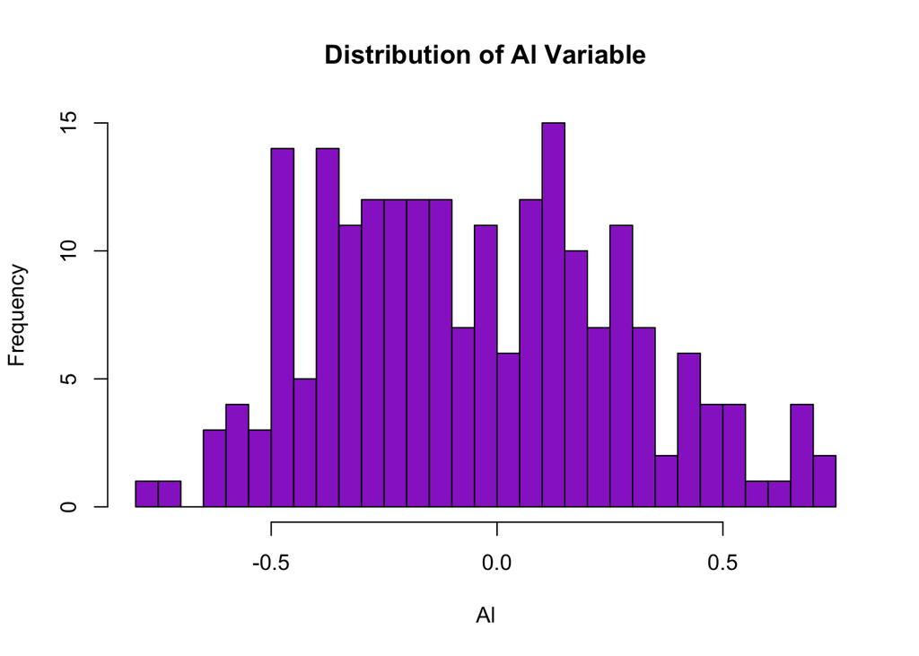

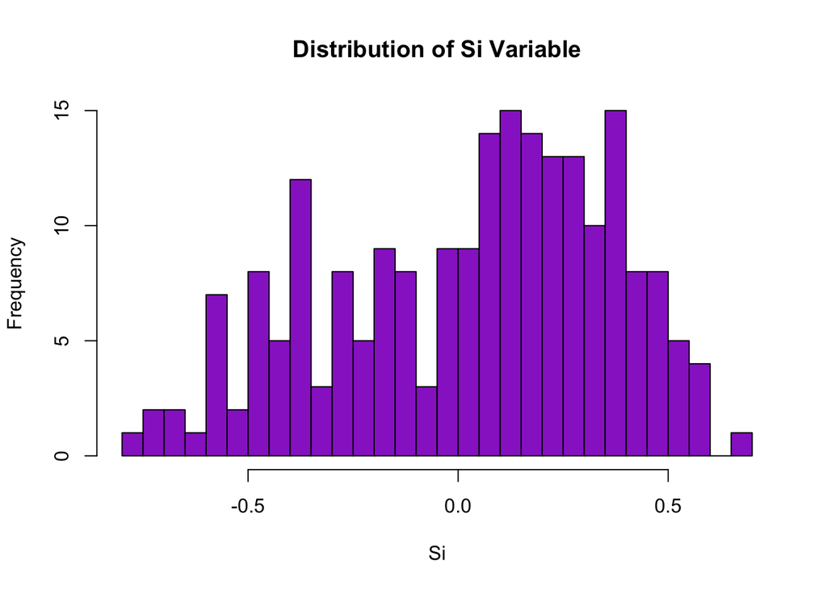

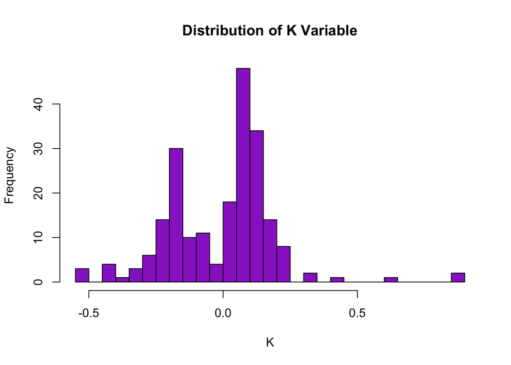

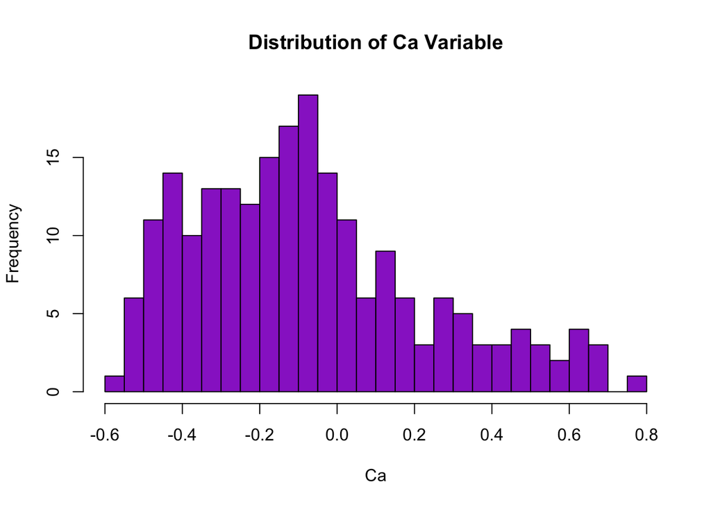

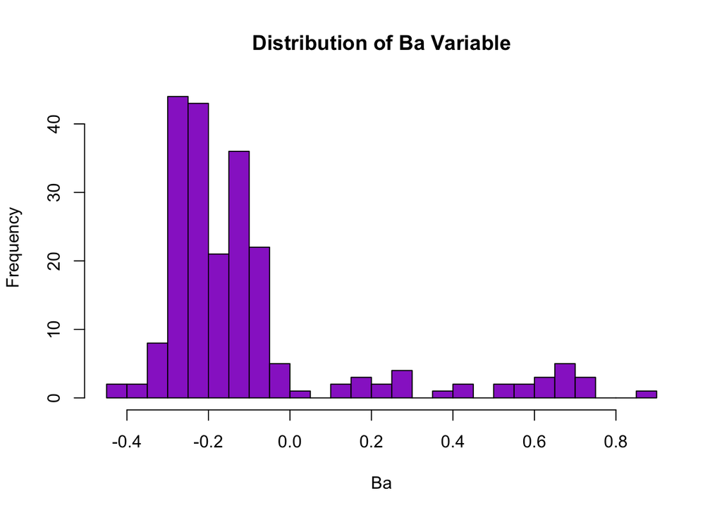

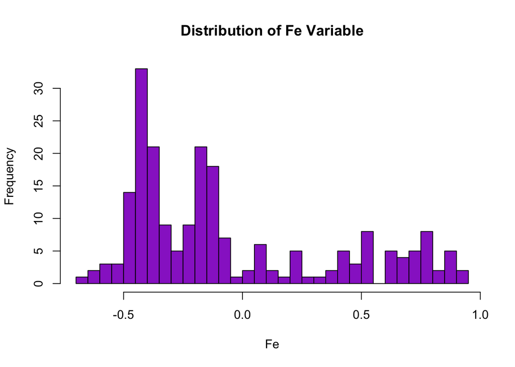

```r
hist_plotter(trans_glass)
```

In looking at the histograms post spatial sign, I think it is pretty clear that these distributions are the most normal and ready for modeling. It could be that custom transforming each variable might prove more robust, but for a simple grooming and pre-processing method, this seems to be the most useful relative to this data set.

## 3.2.

The soybean data can also be found at the UC Irvine Machine Learning Repository. Data were collected to predict disease in 683 soybeans. The 35 predictors are mostly categorical and include information on the environmental conditions (e.g., temperature, precipitation) and plant conditions (e.g., left spots, mold growth). The outcome labels consist of 19 distinct classes. 6 http://archive.ics.uci.edu/ml/index.html.

```r
require(mlbench)
require(caret)
require(corrplot)
#3.1
data(Soybean)
```

**(a) Investigate the frequency distributions for the categorical predictors. Are any of the distributions degenerate in the ways discussed earlier in this chapter?**

A quick look at the head of all 36 columns shows that the categories have been stored as integers where some issues, due the numerical interpretation of cardinal integers, is probably. The data appears to have been ‘binned’ into categorical varibles each, level representibg a range of values.

```r
knitr::kable(head(Soybean[,1:6]))
```

| Class | date | plant.stand | precip | temp | hail |
| --- | --- | --- | --- | --- | --- |
| diaporthe-stem-canker | 6 | 0 | 2 | 1 | 0 |
| diaporthe-stem-canker | 4 | 0 | 2 | 1 | 0 |
| diaporthe-stem-canker | 3 | 0 | 2 | 1 | 0 |
| diaporthe-stem-canker | 3 | 0 | 2 | 1 | 0 |
| diaporthe-stem-canker | 6 | 0 | 2 | 1 | 0 |
| diaporthe-stem-canker | 5 | 0 | 2 | 1 | 0 |

```r
knitr::kable(head(Soybean[,7:12]))
```

| crop.hist | area.dam | sever | seed.tmt | germ | plant.growth |
| --- | --- | --- | --- | --- | --- |
| 1 | 1 | 1 | 0 | 0 | 1 |
| 2 | 0 | 2 | 1 | 1 | 1 |
| 1 | 0 | 2 | 1 | 2 | 1 |
| 1 | 0 | 2 | 0 | 1 | 1 |
| 2 | 0 | 1 | 0 | 2 | 1 |
| 3 | 0 | 1 | 0 | 1 | 1 |

```r
knitr::kable(head(Soybean[,13:19]))
```

| leaves | leaf.halo | leaf.marg | leaf.size | leaf.shread | leaf.malf | leaf.mild |
| --- | --- | --- | --- | --- | --- | --- |
| 1 | 0 | 2 | 2 | 0 | 0 | 0 |
| 1 | 0 | 2 | 2 | 0 | 0 | 0 |
| 1 | 0 | 2 | 2 | 0 | 0 | 0 |
| 1 | 0 | 2 | 2 | 0 | 0 | 0 |
| 1 | 0 | 2 | 2 | 0 | 0 | 0 |
| 1 | 0 | 2 | 2 | 0 | 0 | 0 |

```r
knitr::kable(head(Soybean[,20:25]))
```

| stem | lodging | stem.cankers | canker.lesion | fruiting.bodies | ext.decay |
| --- | --- | --- | --- | --- | --- |
| 1 | 1 | 3 | 1 | 1 | 1 |
| 1 | 0 | 3 | 1 | 1 | 1 |
| 1 | 0 | 3 | 0 | 1 | 1 |
| 1 | 0 | 3 | 0 | 1 | 1 |
| 1 | 0 | 3 | 1 | 1 | 1 |
| 1 | 0 | 3 | 0 | 1 | 1 |

```r
knitr::kable(head(Soybean[,26:31]))
```

| mycelium | int.discolor | sclerotia | fruit.pods | fruit.spots | seed |
| --- | --- | --- | --- | --- | --- |
| 0 | 0 | 0 | 0 | 4 | 0 |
| 0 | 0 | 0 | 0 | 4 | 0 |
| 0 | 0 | 0 | 0 | 4 | 0 |
| 0 | 0 | 0 | 0 | 4 | 0 |
| 0 | 0 | 0 | 0 | 4 | 0 |
| 0 | 0 | 0 | 0 | 4 | 0 |

```r
knitr::kable(head(Soybean[,32:36]))
```

| mold.growth | seed.discolor | seed.size | shriveling | roots |
| --- | --- | --- | --- | --- |
| 0 | 0 | 0 | 0 | 0 |
| 0 | 0 | 0 | 0 | 0 |
| 0 | 0 | 0 | 0 | 0 |
| 0 | 0 | 0 | 0 | 0 |
| 0 | 0 | 0 | 0 | 0 |
| 0 | 0 | 0 | 0 | 0 |

```r
summary(Soybean)
```

```
##                  Class          date     plant.stand  precip      temp
##  brown-spot         : 92   5      :149   0   :354    0   : 74   0   : 80
##  alternarialeaf-spot: 91   4      :131   1   :293    1   :112   1   :374
##  frog-eye-leaf-spot : 91   3      :118   NA's: 36    2   :459   2   :199
##  phytophthora-rot   : 88   2      : 93               NA's: 38   NA's: 30
##  anthracnose        : 44   6      : 90
##  brown-stem-rot     : 44   (Other):101
##  (Other)            :233   NA's   :  1
##    hail     crop.hist  area.dam    sever     seed.tmt     germ
##  0   :435   0   : 65   0   :123   0   :195   0   :305   0   :165
##  1   :127   1   :165   1   :227   1   :322   1   :222   1   :213
##  NA's:121   2   :219   2   :145   2   : 45   2   : 35   2   :193
##             3   :218   3   :187   NA's:121   NA's:121   NA's:112
##             NA's: 16   NA's:  1
##
##
##  plant.growth leaves  leaf.halo  leaf.marg  leaf.size  leaf.shread
##  0   :441     0: 77   0   :221   0   :357   0   : 51   0   :487
##  1   :226     1:606   1   : 36   1   : 21   1   :327   1   : 96
##  NA's: 16             2   :342   2   :221   2   :221   NA's:100
##                       NA's: 84   NA's: 84   NA's: 84
##
##
##
##  leaf.malf  leaf.mild    stem     lodging    stem.cankers canker.lesion
##  0   :554   0   :535   0   :296   0   :520   0   :379     0   :320
##  1   : 45   1   : 20   1   :371   1   : 42   1   : 39     1   : 83
##  NA's: 84   2   : 20   NA's: 16   NA's:121   2   : 36     2   :177
##             NA's:108                         3   :191     3   : 65
##                                              NA's: 38     NA's: 38
##
##
##  fruiting.bodies ext.decay  mycelium   int.discolor sclerotia  fruit.pods
##  0   :473        0   :497   0   :639   0   :581     0   :625   0   :407
##  1   :104        1   :135   1   :  6   1   : 44     1   : 20   1   :130
##  NA's:106        2   : 13   NA's: 38   2   : 20     NA's: 38   2   : 14
##                  NA's: 38              NA's: 38                3   : 48
##                                                                NA's: 84
##
##
##  fruit.spots   seed     mold.growth seed.discolor seed.size  shriveling
##  0   :345    0   :476   0   :524    0   :513      0   :532   0   :539
##  1   : 75    1   :115   1   : 67    1   : 64      1   : 59   1   : 38
##  2   : 57    NA's: 92   NA's: 92    NA's:106      NA's: 92   NA's:106
##  4   :100
##  NA's:106
##
##
##   roots
##  0   :551
##  1   : 86
##  2   : 15
##  NA's: 31
##
##
##
```

Using summary on the `Soybean` data there are clearly a number of categorical variables with missing values, as well as some highly disproportionate distributions of values.

```r
# require(DT)
# for (col in 1:ncol(Soybean)){
#     print('**New Table**')
#     print(colnames(Soybean[col]))
#     print(prop.table(table(Soybean[[col]])))
# }

prop_isna  <- function(col){
    knitr::kable(prop.table(table(is.na(col))))
}

prop_tabler  <- function(col){
    knitr::kable(prop.table(table(col)))
}
```

### Proportion of Each Category per Variable

```r
apply(Soybean, 2, prop_tabler)
```

```
## $Class
##
##
## col                                 Freq
## ----------------------------  ----------
## 2-4-d-injury                   0.0234261
## alternarialeaf-spot            0.1332357
## anthracnose                    0.0644217
## bacterial-blight               0.0292826
## bacterial-pustule              0.0292826
## brown-spot                     0.1346999
## brown-stem-rot                 0.0644217
## charcoal-rot                   0.0292826
## cyst-nematode                  0.0204978
## diaporthe-pod-&-stem-blight    0.0219619
## diaporthe-stem-canker          0.0292826
## downy-mildew                   0.0292826
## frog-eye-leaf-spot             0.1332357
## herbicide-injury               0.0117130
## phyllosticta-leaf-spot         0.0292826
## phytophthora-rot               0.1288433
## powdery-mildew                 0.0292826
## purple-seed-stain              0.0292826
## rhizoctonia-root-rot           0.0292826
##
## $date
##
##
## col         Freq
## ----  ----------
## 0      0.0381232
## 1      0.1099707
## 2      0.1363636
## 3      0.1730205
## 4      0.1920821
## 5      0.2184751
## 6      0.1319648
##
## $plant.stand
##
```

[output cut: 278 more lines]

```
##
##
## col         Freq
## ----  ----------
## 0      0.9341421
## 1      0.0658579
##
## $roots
##
##
## col         Freq
## ----  ----------
## 0      0.8450920
## 1      0.1319018
## 2      0.0230061
```

From the above tables it is clear that there are a number of highly unbalanced classes, such that they might be too skewed to compensate for in normal over/under sampling methods.

Those highly unbalanced cateorical variables are:

mycelium sclerotia seed.size shriveling

And there are many other classes where they are not so extreme but one might still struggle to make use of the variables

**(b) Roughly 18 % of the data are missing. Are there particular predictors that are more likely to be missing? Is the pattern of missing data related to the classes?**

### Complete Cases Relative to the Class Variable

|  | FALSE | TRUE |
| --- | --- | --- |
| 2-4-d-injury | 16 | 0 |
| alternarialeaf-spot | 0 | 91 |
| anthracnose | 0 | 44 |
| bacterial-blight | 0 | 20 |
| bacterial-pustule | 0 | 20 |
| brown-spot | 0 | 92 |
| brown-stem-rot | 0 | 44 |
| charcoal-rot | 0 | 20 |
| cyst-nematode | 14 | 0 |
| diaporthe-pod-&-stem-blight | 15 | 0 |
| diaporthe-stem-canker | 0 | 20 |
| downy-mildew | 0 | 20 |
| frog-eye-leaf-spot | 0 | 91 |
| herbicide-injury | 8 | 0 |
| phyllosticta-leaf-spot | 0 | 20 |
| phytophthora-rot | 68 | 20 |
| powdery-mildew | 0 | 20 |
| purple-seed-stain | 0 | 20 |
| rhizoctonia-root-rot | 0 | 20 |

From the ablove table, it is clear that there are four Classes with ZERO complete cases. This is means that using `drop_na()` would elminate whole sample classes of soybeans:

2-4-d-injury  
cyst-nematode  
herbicide-injury  
diaporthe-pod-&-stem-blight

### Missing Values

Missing Values percents for each variable in in the data frame:

| Missing Status | Percent |
| --- | --- |
| FALSE | 0.9049536 |
| TRUE | 0.0950464 |

```r
require(tidyr)
#for next heading
Soy_mis <- Soybean%>%
    drop_na()

# looking at all variables one at a time
for(col in colnames(Soybean)){
    print(col)
    print(prop.table(table(is.na(Soybean[,col]))))
}
```

```
## [1] "Class"
##
## FALSE
##     1
## [1] "date"
##
##       FALSE        TRUE
## 0.998535871 0.001464129
## [1] "plant.stand"
##
##      FALSE       TRUE
## 0.94729136 0.05270864
## [1] "precip"
##
##     FALSE      TRUE
## 0.9443631 0.0556369
## [1] "temp"
##
##      FALSE       TRUE
## 0.95607613 0.04392387
## [1] "hail"
##
##     FALSE      TRUE
## 0.8228404 0.1771596
## [1] "crop.hist"
##
##      FALSE       TRUE
## 0.97657394 0.02342606
## [1] "area.dam"
##
##       FALSE        TRUE
## 0.998535871 0.001464129
## [1] "sever"
##
##     FALSE      TRUE
## 0.8228404 0.1771596
## [1] "seed.tmt"
##
##     FALSE      TRUE
## 0.8228404 0.1771596
```

[output cut: 89 more lines]

```
##
##     FALSE      TRUE
## 0.8448023 0.1551977
## [1] "seed.size"
##
##     FALSE      TRUE
## 0.8653001 0.1346999
## [1] "shriveling"
##
##     FALSE      TRUE
## 0.8448023 0.1551977
## [1] "roots"
##
##      FALSE       TRUE
## 0.95461201 0.04538799
```

Many of these variables share the same percent of missing values, which might imply that they are not missing completely at random, but are missing relative to other variables in the same observations.

### Number of observations left if `drop_na()` is used

*Number of Observations in Whole Data Set:* 683

*Number of Observations NA removed:* 562

## What does removing NA look like for each variable?

If we were to `drop_na()` this is how many individual rows we would eleminate along with all of most of the 5 mentioned prior classes.

```r
require(tidyr)
Soy_mis <- Soybean%>%
    drop_na()
knitr::kable(sort(apply(Soybean, 2, function(x) sum(is.na(x)))),col.names = c( 'Missing Values'))
```

|  | Missing Values |
| --- | --- |
| Class | 0 |
| leaves | 0 |
| date | 1 |
| area.dam | 1 |
| crop.hist | 16 |
| plant.growth | 16 |
| stem | 16 |
| temp | 30 |
| roots | 31 |
| plant.stand | 36 |
| precip | 38 |
| stem.cankers | 38 |
| canker.lesion | 38 |
| ext.decay | 38 |
| mycelium | 38 |
| int.discolor | 38 |
| sclerotia | 38 |
| leaf.halo | 84 |
| leaf.marg | 84 |
| leaf.size | 84 |
| leaf.malf | 84 |
| fruit.pods | 84 |
| seed | 92 |
| mold.growth | 92 |
| seed.size | 92 |
| leaf.shread | 100 |
| fruiting.bodies | 106 |
| fruit.spots | 106 |
| seed.discolor | 106 |
| shriveling | 106 |
| leaf.mild | 108 |
| germ | 112 |
| hail | 121 |
| sever | 121 |
| seed.tmt | 121 |
| lodging | 121 |

If you look at the number of rows left when you drop all rows with na values, it is 121 less than the total number of rows. This would suggest that in every row where hail, sever, sed.tmt and lodging is missing some of the other variables are missing too.

A summary of Missing Values in `hail` by Class below, shows that there are definite relationships relative to Class

**Hail**

```r
require(dplyr)
Soybean%>%
    dplyr::group_by(Class)%>%
    summarise(class_count = n(),
              na_count = sum(is.na(hail)))%>%
    mutate(percent_na = na_count/class_count)%>%knitr::kable()
```

[output not shown]

```r
Soybean%>%
    dplyr::group_by(Class)%>%
    summarise(class_count = n(),
              na_count = sum(is.na(leaf.marg)))%>%
    mutate(percent_na = na_count/class_count)%>%knitr::kable()
```

| Class | class_count | na_count | percent_na |
| --- | --- | --- | --- |
| 2-4-d-injury | 16 | 0 | 0.000 |
| alternarialeaf-spot | 91 | 0 | 0.000 |
| anthracnose | 44 | 0 | 0.000 |
| bacterial-blight | 20 | 0 | 0.000 |
| bacterial-pustule | 20 | 0 | 0.000 |
| brown-spot | 92 | 0 | 0.000 |
| brown-stem-rot | 44 | 0 | 0.000 |
| charcoal-rot | 20 | 0 | 0.000 |
| cyst-nematode | 14 | 14 | 1.000 |
| diaporthe-pod-&-stem-blight | 15 | 15 | 1.000 |
| diaporthe-stem-canker | 20 | 0 | 0.000 |
| downy-mildew | 20 | 0 | 0.000 |
| frog-eye-leaf-spot | 91 | 0 | 0.000 |
| herbicide-injury | 8 | 0 | 0.000 |
| phyllosticta-leaf-spot | 20 | 0 | 0.000 |
| phytophthora-rot | 88 | 55 | 0.625 |
| powdery-mildew | 20 | 0 | 0.000 |
| purple-seed-stain | 20 | 0 | 0.000 |
| rhizoctonia-root-rot | 20 | 0 | 0.000 |

**fruit.spots**

```r
Soybean%>%
    dplyr::group_by(Class)%>%
    summarise(class_count = n(),
              na_count = sum(is.na(fruit.spots)))%>%
    mutate(percent_na = na_count/class_count)%>%knitr::kable()
```

| Class | class_count | na_count | percent_na |
| --- | --- | --- | --- |
| 2-4-d-injury | 16 | 16 | 1.0000000 |
| alternarialeaf-spot | 91 | 0 | 0.0000000 |
| anthracnose | 44 | 0 | 0.0000000 |
| bacterial-blight | 20 | 0 | 0.0000000 |
| bacterial-pustule | 20 | 0 | 0.0000000 |
| brown-spot | 92 | 0 | 0.0000000 |
| brown-stem-rot | 44 | 0 | 0.0000000 |
| charcoal-rot | 20 | 0 | 0.0000000 |
| cyst-nematode | 14 | 14 | 1.0000000 |
| diaporthe-pod-&-stem-blight | 15 | 0 | 0.0000000 |
| diaporthe-stem-canker | 20 | 0 | 0.0000000 |
| downy-mildew | 20 | 0 | 0.0000000 |
| frog-eye-leaf-spot | 91 | 0 | 0.0000000 |
| herbicide-injury | 8 | 8 | 1.0000000 |
| phyllosticta-leaf-spot | 20 | 0 | 0.0000000 |
| phytophthora-rot | 88 | 68 | 0.7727273 |
| powdery-mildew | 20 | 0 | 0.0000000 |
| purple-seed-stain | 20 | 0 | 0.0000000 |
| rhizoctonia-root-rot | 20 | 0 | 0.0000000 |

In all cases, the missing values are from Classes:

2-4-d-injury  
cyst-nematode  
herbicide-injury  
diaporthe-pod-&-stem-blight  
phytophthora-rot

Evaluating the Class Counts with NA values removed, may be helpful in forming a plan moving forward.

Number of Classes in Original Data: 19

Number of Classes in set with Dropped Na: 15

Number of Columns without NA Values : 2

**(c) Develop a strategy for handling missing data, either by eliminating predictors or imputation.**

There is no simple method of handling missing data in this data set AND preserving the global utility of the data. Because the classes with missing data have many incomplete variables in the observations, any for of imputation which might be useful in the less empty classes would introduce a lot of error into those 5 classes.

If some form of imputation (MICE is my go-to package) it would be important to create another variable for each imputed variable that was a 0 1 flag indicating whether or not that variable was imputed for that observation. This would allow models with high sensistivity to this sort of handling to use the native values differently than the imputed values by attributing the bias to the ‘flag’ variable. I have used this in logistic regression models with some success. It may also be useful to use a PCA to or LDA to extract the most variance in a smaller sample of the variables.

It could be useful to simply purge the most empty 4 (or 5 ) classes and move forward with imputation on the rest. or to remove the 4 emptiest classes, establish which variables are most important using PCA, then see how those variables are represented by the 4 fragile classes with high NA counts…if theh are less impacted, it might be possible to impute across the remaining variables for all classes using flags for imputed values and preserve a pretty high level of predictive power.